# LABORATORIO N° 01 — MINERÍA DE DATOS

**Semana 1: Exploración Inicial de un Dataset**  
**Docente:** Pilar Rocio Sayan Mejia | TECSUP 2026-I  
**Dataset:** Telco Customer Churn

# Exploración Inicial de un Dataset

**Curso:** Minería de Datos  
**Docente:** Pilar Rocio Sayan Mejia  
**Semana:** 1 — Introducción a la Minería de Datos

**Alumno(a):** ARTEAGA GUERRA PEDRO  
**Fecha:** 20/03/2026

## Actividad 1: Revisión de conceptos

Complete la siguiente tabla con definiciones propias basadas en lo estudiado en la clase teórica.  
**No copie textualmente del material; use sus propias palabras.**

| Concepto / Principio | Definición con sus propias palabras |
| --- | --- |
| **1. Minería de datos** | *Es el arte de descubrir patrones y tendencias en grandes volúmenes de datos* |
| **2. Proceso KDD (Knowledge Discovery in Databases)** | *es el arte de repetir 5 fases para descubrir patrones y tendendias ocultas vitales para el modelo* |
| **3. Clasificación** | *es el arte de agrupar datos con tendencias lo más parecidas para separarlos del resto* |
| **4. Regresión** | *es uno de los tantos modelos que en este caso sirve para predecir datos en base a otros factores* |
| **5. Clustering** | *Es el arte de agrupar datos mediante patrones/relaciones ocultas en conjuntos* |
| **6. Aprendizaje supervisado vs. no supervisado** | *La gran diferencia sería la necesidad de la intervención humana* |
| **7. Análisis Exploratorio de Datos (EDA)** | *Es una de las partes mas importantes ya que te permite ver y entender la distribución de los datos* |
| **8. ¿Qué relación tiene la minería de datos con Machine Learning?** | *Podríamos decir que el machine Learning es la parte general y la minería de datos está más enfocado* |

## Actividad 2: Desarrollo práctico — Exploración del Dataset

En esta actividad explorarás el dataset **Telco Customer Churn**, que contiene información de clientes de una empresa de telecomunicaciones.

La variable objetivo es **"Churn"**, que indica si el cliente canceló o no su contrato.

### Paso 1: Cargar el dataset

En esta sección cargaremos el dataset **Telco Customer Churn** y realizaremos una exploración inicial de los datos.

Este dataset contiene información de clientes de una empresa de telecomunicaciones y la variable **Churn** indica si el cliente canceló o no su servicio.

```python
import pandas as pd
import numpy as np
import matplotlib.pyplot as plt
import seaborn as sns
import warnings

warnings.filterwarnings('ignore')
```

```python
plt.style.use('seaborn-v0_8-whitegrid')
sns.set_palette('Set2')

plt.rcParams['figure.dpi'] = 100
plt.rcParams['font.size'] = 11
```

```python
url = "https://raw.githubusercontent.com/IBM/telco-customer-churn-on-icp4d/master/data/Telco-Customer-Churn.csv"

df = pd.read_csv(url)

df.head()
```

|  | customerID | gender | SeniorCitizen | Partner | Dependents | tenure | PhoneService | MultipleLines | InternetService | OnlineSecurity | ... | DeviceProtection | TechSupport | StreamingTV | StreamingMovies | Contract | PaperlessBilling | PaymentMethod | MonthlyCharges | TotalCharges | Churn |
| --- | --- | --- | --- | --- | --- | --- | --- | --- | --- | --- | --- | --- | --- | --- | --- | --- | --- | --- | --- | --- | --- |
| 0 | 7590-VHVEG | Female | 0 | Yes | No | 1 | No | No phone service | DSL | No | ... | No | No | No | No | Month-to-month | Yes | Electronic check | 29.85 | 29.85 | No |
| 1 | 5575-GNVDE | Male | 0 | No | No | 34 | Yes | No | DSL | Yes | ... | Yes | No | No | No | One year | No | Mailed check | 56.95 | 1889.5 | No |
| 2 | 3668-QPYBK | Male | 0 | No | No | 2 | Yes | No | DSL | Yes | ... | No | No | No | No | Month-to-month | Yes | Mailed check | 53.85 | 108.15 | Yes |
| 3 | 7795-CFOCW | Male | 0 | No | No | 45 | No | No phone service | DSL | Yes | ... | Yes | Yes | No | No | One year | No | Bank transfer (automatic) | 42.30 | 1840.75 | No |
| 4 | 9237-HQITU | Female | 0 | No | No | 2 | Yes | No | Fiber optic | No | ... | No | No | No | No | Month-to-month | Yes | Electronic check | 70.70 | 151.65 | Yes |

5 rows × 21 columns

```python
print(f"Dimensiones del dataset: {df.shape}")
print(f"Filas: {df.shape[0]}")
print(f"Columnas: {df.shape[1]}")
```

```
Dimensiones del dataset: (7043, 21)
Filas: 7043
Columnas: 21
```

[output not shown]

**Pregunta 1:**  
¿Cuántas filas y cuántas columnas tiene el dataset?

**Respuesta 1:**  
*Como se muestra arriba se ven que son 7043 filas y 21 columnas aunque es redundante decirlo*

### Paso 2: Conocer la estructura del dataset

```python
df.info()
```

```
<class 'pandas.core.frame.DataFrame'>
RangeIndex: 7043 entries, 0 to 7042
Data columns (total 21 columns):
 #   Column            Non-Null Count  Dtype
---  ------            --------------  -----
 0   customerID        7043 non-null   object
 1   gender            7043 non-null   object
 2   SeniorCitizen     7043 non-null   int64
 3   Partner           7043 non-null   object
 4   Dependents        7043 non-null   object
 5   tenure            7043 non-null   int64
 6   PhoneService      7043 non-null   object
 7   MultipleLines     7043 non-null   object
 8   InternetService   7043 non-null   object
 9   OnlineSecurity    7043 non-null   object
 10  OnlineBackup      7043 non-null   object
 11  DeviceProtection  7043 non-null   object
 12  TechSupport       7043 non-null   object
 13  StreamingTV       7043 non-null   object
 14  StreamingMovies   7043 non-null   object
 15  Contract          7043 non-null   object
 16  PaperlessBilling  7043 non-null   object
 17  PaymentMethod     7043 non-null   object
 18  MonthlyCharges    7043 non-null   float64
 19  TotalCharges      7043 non-null   object
 20  Churn             7043 non-null   object
dtypes: float64(1), int64(2), object(18)
memory usage: 1.1+ MB
```

```python
#Tipos de variables
df.dtypes.value_counts()
```

|  | count |
| --- | --- |
| object | 18 |
| int64 | 2 |
| float64 | 1 |

**dtype:** int64

```python
# Nombres de las columnas
print(df.columns.tolist())
```

[output not shown]

### Paso 3: Limpieza inicial y estadísticas descriptivas

**Pregunta 2:** ¿Cuántas variables numéricas y cuántas categóricas identificas? Escribe 3 ejemplos de cada tipo.

*Respuesta: serian 3 tipos de datos,Objetc(customerID,gender,Partner),Int64(SeniorCitizen) y float64(MonthlyCarges)*

**Pregunta 3:** ¿Qué representa cada fila del dataset? ¿Qué representa la columna "Churn"?

*Respuesta: cada fila representa los datos del dataset y la churn seria la variable objetivo o la mas importante*

**Pregunta 4:** ¿Cuál es el promedio de tenure (meses de antigüedad)? ¿Y la mediana? ¿Qué te dice la diferencia entre ambas?

*Respuesta: que primero, el promedio de tenure serian 32 nos dice que los clientes en promedio tienen 32 meses con el servicio *

```python
df['TotalCharges'] = pd.to_numeric(df['TotalCharges'], errors='coerce')
df['Churn_num'] = df['Churn'].map({'Yes':1,'No':0})

df.describe()
```

|  | SeniorCitizen | tenure | MonthlyCharges | TotalCharges | Churn_num |
| --- | --- | --- | --- | --- | --- |
| count | 7043.000000 | 7043.000000 | 7043.000000 | 7032.000000 | 7043.000000 |
| mean | 0.162147 | 32.371149 | 64.761692 | 2283.300441 | 0.265370 |
| std | 0.368612 | 24.559481 | 30.090047 | 2266.771362 | 0.441561 |
| min | 0.000000 | 0.000000 | 18.250000 | 18.800000 | 0.000000 |
| 25% | 0.000000 | 9.000000 | 35.500000 | 401.450000 | 0.000000 |
| 50% | 0.000000 | 29.000000 | 70.350000 | 1397.475000 | 0.000000 |
| 75% | 0.000000 | 55.000000 | 89.850000 | 3794.737500 | 1.000000 |
| max | 1.000000 | 72.000000 | 118.750000 | 8684.800000 | 1.000000 |

*Pregunta 5:** ¿Hay valores nulos en el dataset? ¿En qué columna(s)? ¿Cuántos son?

*Respuesta: hay 11 datos nulos en TotalCharges*

```python
df['TotalCharges'] = pd.to_numeric(df['TotalCharges'], errors='coerce')
print(f'Valores nulos en TotalCharges después de la conversión: {df["TotalCharges"].isnull().sum()}')
```

```
Valores nulos en TotalCharges después de la conversión: 11
```

```python
# Codificar Churn como numérico para análisis de correlación posterior
df['Churn_num'] = df['Churn'].map({'Yes': 1, 'No': 0})

# Estadísticas descriptivas (ahora TotalCharges aparece correctamente)
df.describe()

# Verificar valores nulos en todo el dataset
df.isnull().sum()
```

|  | 0 |
| --- | --- |
| customerID | 0 |
| gender | 0 |
| SeniorCitizen | 0 |
| Partner | 0 |
| Dependents | 0 |
| tenure | 0 |
| PhoneService | 0 |
| MultipleLines | 0 |
| InternetService | 0 |
| OnlineSecurity | 0 |
| OnlineBackup | 0 |
| DeviceProtection | 0 |
| TechSupport | 0 |
| StreamingTV | 0 |
| StreamingMovies | 0 |
| Contract | 0 |
| PaperlessBilling | 0 |
| PaymentMethod | 0 |
| MonthlyCharges | 0 |
| TotalCharges | 11 |
| Churn | 0 |
| Churn_num | 0 |

**dtype:** int64

#### Paso 4: Distribución de la variable objetivo

Analiza cómo se distribuye la variable Churn:

```
Churn
No     5174
Yes    1869
Name: count, dtype: int64

Porcentaje de churn: Churn
No     73.463013
Yes    26.536987
Name: proportion, dtype: float64
```

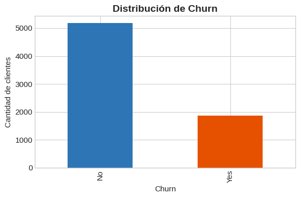

```python
 # Distribución de Churn
print(df['Churn'].value_counts())
print(f'\nPorcentaje de churn: {df["Churn"].value_counts(normalize=True)*100}')

# Gráfico de barras
fig, ax = plt.subplots(figsize=(6, 4))
df['Churn'].value_counts().plot(kind='bar', color=['#2E75B6', '#E65100'], ax=ax)
ax.set_title('Distribución de Churn', fontsize=14, fontweight='bold')
ax.set_xlabel('Churn')
ax.set_ylabel('Cantidad de clientes')
plt.tight_layout()
plt.show()
```

**Pregunta 6:** ¿El dataset está balanceado (las dos clases tienen cantidades similares) o desbalanceado? ¿Qué porcentaje de clientes canceló su contrato? ¿Por qué es importante saber esto antes de entrenar un modelo?

*Respuesta: Hay un gran desvalance entre los clientes que si(26%) y no(74%) han renovado contrato y al tener este desvalance puede afectar al al aprendizaje del modelo ya que puede estar sesgado*

#### Paso 5: Visualización exploratoria

Genera las siguientes visualizaciones para explorar relaciones en los datos:

**Pregunta 7:** Observando el histograma de tenure: ¿Los clientes que cancelan tienden a tener más o menos antigüedad? ¿Qué hipótesis podrías formular?

*Respuesta: A menor tiempo tenga el cliente es mas probable que cancele el servicio ya sea porque o no le ha gustado el servicio o por otros factores*

**Pregunta 8:** Observando el boxplot de MonthlyCharges: ¿Los clientes que cancelan pagan más o menos por mes? ¿Qué podría explicar esto?

**Pregunta 9:** ¿Qué tipo de contrato tiene mayor tasa de churn? ¿Por qué tiene sentido desde el punto de vista del negocio?

*Respuesta: Serian los de Month a Month ya que es mas facil cancelar algo que pagas una vez al mes a diferencia si es una vez al año algo asi como, ya lo pague para que lo voy a cancelar si es un año entero*

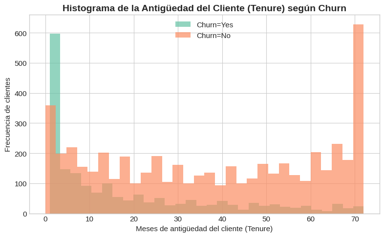

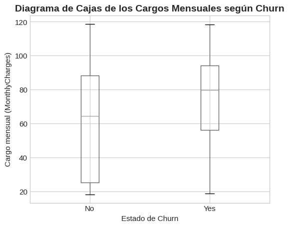

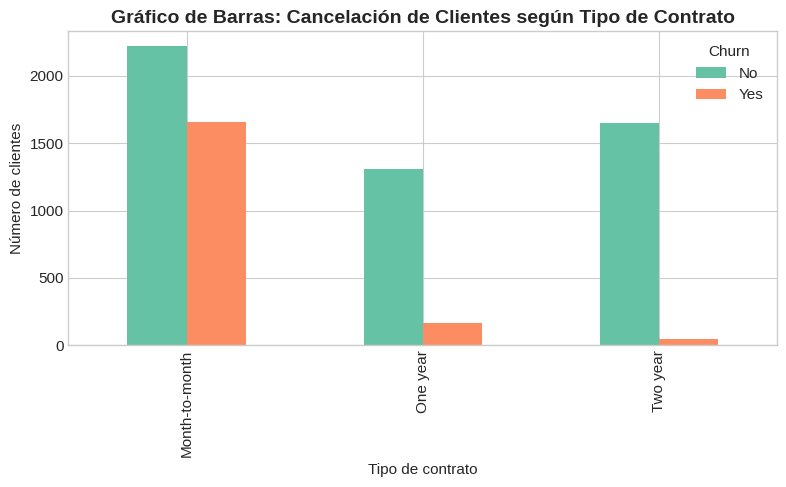

```python
# Histograma de tenure por Churn
fig, ax = plt.subplots(figsize=(8, 5))
df[df['Churn']=='Yes']['tenure'].hist(alpha=0.7, label='Churn=Yes', bins=30, ax=ax)
df[df['Churn']=='No']['tenure'].hist(alpha=0.7, label='Churn=No', bins=30, ax=ax)
ax.set_title('Histograma de la Antigüedad del Cliente (Tenure) según Churn',fontsize=14, fontweight='bold')
ax.set_xlabel('Meses de antigüedad del cliente (Tenure)')
ax.legend()
ax.set_ylabel('Frecuencia de clientes')
plt.tight_layout()
plt.show()

# Diagrama de cajas de MonthlyCharges por Churn
fig, ax = plt.subplots(figsize=(6, 5))
df.boxplot(column='MonthlyCharges', by='Churn', ax=ax)
ax.set_title('Diagrama de Cajas de los Cargos Mensuales según Churn',
             fontsize=14, fontweight='bold')
plt.suptitle('')
ax.set_xlabel('Estado de Churn')
ax.set_ylabel('Cargo mensual (MonthlyCharges)')

# Churn por tipo de contrato
fig, ax = plt.subplots(figsize=(8, 5))
pd.crosstab(df['Contract'], df['Churn']).plot(kind='bar', ax=ax)
ax.set_title('Gráfico de Barras: Cancelación de Clientes según Tipo de Contrato',
             fontsize=14, fontweight='bold')
ax.set_xlabel('Tipo de contrato')
ax.set_ylabel('Número de clientes')
plt.tight_layout()
plt.show()
```

#### Paso 6: Matriz de correlación

Genera una matriz de correlación para las variables numéricas:

**Pregunta 10:** ¿Qué par de variables tiene la correlación más alta? ¿Tiene sentido lógico? Explica. Además, ¿qué variables muestran mayor correlación con Churn_num?

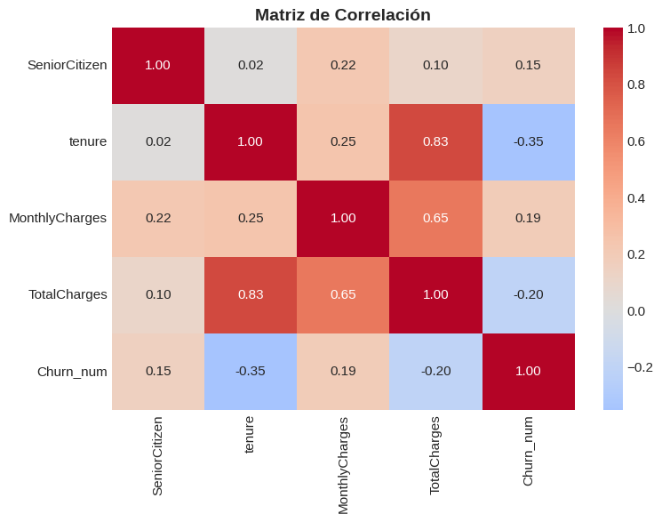

```python
# Seleccionar solo variables numéricas (incluye Churn_num)
num_cols = df.select_dtypes(include=[np.number]).columns
corr_matrix = df[num_cols].corr()

# Heatmap
fig, ax = plt.subplots(figsize=(8, 6))
sns.heatmap(corr_matrix, annot=True, cmap='coolwarm', center=0, fmt='.2f', ax=ax)
ax.set_title('Matriz de Correlación', fontsize=14, fontweight='bold')
plt.tight_layout()
plt.show()
```

## Actividad 3: Caso de estudio — Análisis para la toma de decisiones

**Contexto del caso:** Eres analista de datos junior en TelcoPerú, una empresa de telecomunicaciones. Tu jefe te ha pedido un informe preliminar sobre la situación del churn de clientes. Aún no vas a construir modelos predictivos (eso vendrá en semanas posteriores), pero necesitas presentar los hallazgos de tu exploración inicial para que el equipo de negocio tome decisiones.

**Entregable esperado:** Responde las siguientes preguntas en celdas de texto (Markdown) de tu notebook de Colab.

**Pregunta A:** ¿Este problema de negocio (predecir churn) es de clasificación, regresión o clustering? Justifica tu respuesta.

*Respuesta: Diria que es de Regresion es decir de clasificacion ya que la variable objetivo se divide en 1/0,si/no,tiene/no tiene lo cual seria una clasificacion binaria y en esto destaca la regresion logistica *

**Pregunta B:** Basado en tu exploración, ¿cuáles son las 3 variables que consideras más importantes para predecir el churn? Justifica con los gráficos que generaste.

*Respuesta: TotalChargues y Montlycharges y por ultimo tenure

Los de Mes a Mes ya que es mas facil cancelar algo que pagas una vez al mes a diferencia si es una vez al año algo asi como, ya lo pague para que lo voy a cancelar si es un año entero

Los clientes que acomulan un mayor gasto mensual tienden es mas probable que cancele y biceversa

A menor tiempo tenga el cliente es mas probable que cancele el servicio ya sea porque o no le ha gustado el servicio o por otros factores *

**Pregunta C:** ¿Qué fase del proceso KDD acabas de realizar en este laboratorio? Describe brevemente cada paso que seguiste.

**Pregunta D:** Si fueras a construir un modelo predictivo (en semanas futuras), ¿sería aprendizaje supervisado o no supervisado? ¿Por qué?

*Respuesta: seria supervisado ya que ya tenemos la variable ojetivo dividida entre 1/0 si/no pero si tuviera mas tiempo haria el no supervizado para jugar mas con los datos*

**Pregunta E:** Escribe 3 recomendaciones de negocio para TelcoPerú basadas únicamente en lo que observaste en los datos. No necesitas modelos, solo tus observaciones.

*Respuesta: 1 Proponer estrategias de retencion para los nuevos clientes ya que si bien la tasa de cancelacion es del 26% se puede hacer mas pequeña lo que se traduce en mas ingresos

2 crear promociones/precios y beneficios variables para los clientes con cargos fuertes/altos ya que tienen una mayor tendencia a avandonar el servicio

3 propondria que hallan unicamente 2 tipos de contratos los mensuales y los anuales pero le daria principal importancia o atencion a los contratos de un año ya que mientras un cliente tenga un mayor tiempo de permanencia es menos probable que cancele el servicio*

### Conclusiones

Escriba las conclusiones técnicas y de aprendizaje obtenidas tras la práctica:

## Material complementario

1. Gironés Roig, J. et al. (2017). *Minería de datos: modelos y algoritmos*. Editorial UOC. Capítulo 1.
2. Provost, F. y Fawcett, T. (2013). *Data Science for Business*. O'Reilly. Capítulo 1.
3. Kaggle: Telco Customer Churn Dataset — https://www.kaggle.com/datasets/blastchar/telco-customer-churn
4. Video: "¿Qué es la minería de datos?" — buscar en YouTube canal "Dot CSV" o "AulaDS".

## Criterios de evaluación — Rúbrica holística

**Curso:** Minería de Datos  
**Actividad:** Laboratorio 1 — Exploración Inicial de un Dataset  
**Docente:** Pilar Rocio Sayan Mejia  
**Semana:** 1

| Criterio | Excelente (4) | Bueno (3) | Requiere mejora (2) | No aceptable (1) |
| --- | --- | --- | --- | --- |
| **1. Revisión de conceptos (Act. 1)** | Todas las definiciones son correctas, completas y usan lenguaje técnico | Mayoría correctas con pequeños errores | Definiciones incompletas o parcialmente correctas | No completa o definiciones incorrectas |
| **2. Carga y exploración del dataset (Act. 2)** | Código ejecuta sin errores y sigue buenas prácticas básicas, todas las preguntas respondidas correctamente | Código funciona con mínimos ajustes, mayoría de respuestas correctas | Código con errores, respuestas incompletas | No ejecuta o no responde preguntas |
| **3. Visualización y análisis (Act. 2)** | Gráficos correctos, interpretaciones profundas y bien argumentadas | Gráficos correctos, interpretaciones adecuadas | Gráficos con errores o interpretaciones superficiales | No genera gráficos o no interpreta |
| **4. Caso de estudio (Act. 3)** | Análisis completo con hallazgos relevantes y recomendaciones de negocio | Análisis adecuado con hallazgos básicos | Análisis incompleto | No realiza el caso |
| **5. Conclusiones y presentación** | Conclusiones técnicas claras, redacción impecable, entrega puntual | Conclusiones correctas, buena redacción | Conclusiones vagas o con errores de redacción | No presenta conclusiones |

| Acciones a cumplir | Puntaje |
| --- | --- |
| Puntualidad y dedicación | 1 |
| Cumplimiento de tiempos establecidos | 1 |
| Conclusiones: ortografía y redacción | 1 |
| **Puntaje total** |  |

```python
# Calcular asimetría (skewness) de las variables numéricas
# Regla: si |skewness| > 0.5 → la distribución NO es simétrica → no usar t-Student

print('Asimetría (skewness) de variables numéricas:')
print('─' * 45)

for col in ['tenure', 'MonthlyCharges', 'TotalCharges']:
    skew = df[col].skew()
    normal = '✓ Simétrica' if abs(skew) < 0.5 else '✗ Asimétrica → usar Mann-Whitney'
    print(f'  {col:<20}  skewness = {skew:+.3f}   {normal}')
```

```
Asimetría (skewness) de variables numéricas:
─────────────────────────────────────────────
  tenure                skewness = +0.240   ✓ Simétrica
  MonthlyCharges        skewness = -0.221   ✓ Simétrica
  TotalCharges          skewness = +0.962   ✗ Asimétrica → usar Mann-Whitney
```

**Pregunta 1:** ¿Qué significa que una variable tenga asimetría positiva (skewness > 0)? ¿Qué dice eso sobre la forma de su distribución?

**Respuesta 1:** *indica que es asimetrica es decir tiene una cola positiva osea tiene varios datos grandes positivos*

## Paso 2: Test de Mann-Whitney U — Variables numéricas

### ¿Qué es el test Mann-Whitney U?

Es un test **no paramétrico**: no requiere que los datos sean normales. Compara si la distribución de una variable es diferente entre **dos grupos independientes**.

| Elemento | Descripción |
| --- | --- |
| **H₀ (hipótesis nula)** | La distribución de la variable es IGUAL en ambos grupos |
| **H₁ (hipótesis alternativa)** | Existen diferencias entre los grupos |
| **p-value < 0.05** | Rechazamos H₀ → la diferencia es estadísticamente real |
| **p-value ≥ 0.05** | No podemos rechazar H₀ → no hay evidencia suficiente |

> 💡 **Para entenderlo:** Si el p-value es 0.001, significa que la probabilidad de observar esta diferencia por puro azar es del 0.1%. Casi imposible. La diferencia es real.

```python
import scipy.stats as stats

# Separar los dos grupos
grupo_churn_si = df[df['Churn'] == 'Yes']
grupo_churn_no = df[df['Churn'] == 'No']

print('TEST DE MANN-WHITNEY U')
print('H₀: La distribución es igual en ambos grupos')
print('Nivel de significancia: α = 0.05')
print('─' * 70)
print(f'{"Variable":<20} {"Media Churn=Sí":>15} {"Media Churn=No":>15} {"p-value":>12} {"Conclusión"}')
print('─' * 70)

resultados_mw = {}

for col in ['tenure', 'MonthlyCharges', 'TotalCharges']:
    g1 = grupo_churn_si[col].dropna()
    g2 = grupo_churn_no[col].dropna()

    stat, pval = stats.mannwhitneyu(g1, g2, alternative='two-sided')
    resultados_mw[col] = pval

    conclusion = '✓ DIFERENCIA REAL' if pval < 0.05 else '✗ Sin diferencia'
    print(f'{col:<20} {g1.mean():>15.2f} {g2.mean():>15.2f} {pval:>12.6f}  {conclusion}')
```

```
TEST DE MANN-WHITNEY U
H₀: La distribución es igual en ambos grupos
Nivel de significancia: α = 0.05
──────────────────────────────────────────────────────────────────────
Variable              Media Churn=Sí  Media Churn=No      p-value Conclusión
──────────────────────────────────────────────────────────────────────
tenure                         17.98           37.57     0.000000  ✓ DIFERENCIA REAL
MonthlyCharges                 74.44           61.27     0.000000  ✓ DIFERENCIA REAL
TotalCharges                 1531.80         2555.34     0.000000  ✓ DIFERENCIA REAL
```

```
La hipótesis nula (H₀) indica que no hay diferencias entre los grupos. Por ejemplo, que los clientes que cancelan y los que no cancelan tienen el mismo comportamiento en una variable como MonthlyCharges.
La hipótesis alternativa (H₁) indica que sí hay diferencias entre los grupos.
```

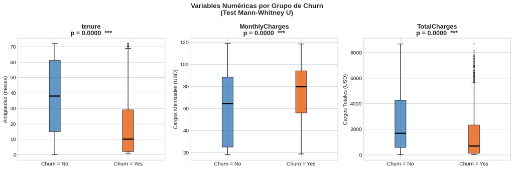

```python
# Visualización: boxplots con resultado del test incorporado
fig, axes = plt.subplots(1, 3, figsize=(15, 5))
fig.suptitle('Variables Numéricas por Grupo de Churn\n(Test Mann-Whitney U)',
             fontsize=14, fontweight='bold')

labels_ejes = ['Antigüedad (meses)', 'Cargos Mensuales (USD)', 'Cargos Totales (USD)']

# Define COLORES_CHURN here
COLORES_CHURN = {'No': '#2E75B6', 'Yes': '#E65100'}

for i, (col, label) in enumerate(zip(['tenure', 'MonthlyCharges', 'TotalCharges'], labels_ejes)):
    datos = [grupo_churn_no[col].dropna(), grupo_churn_si[col].dropna()]
    bp = axes[i].boxplot(datos, patch_artist=True,
                         medianprops={'color': 'black', 'linewidth': 2.5},
                         flierprops={'marker': 'o', 'markersize': 2, 'alpha': 0.3})
    for patch, color in zip(bp['boxes'], [COLORES_CHURN['No'], COLORES_CHURN['Yes']]):
        patch.set_facecolor(color)
        patch.set_alpha(0.75)

    pval = resultados_mw[col]
    estrellas = '***' if pval < 0.001 else '**' if pval < 0.01 else '*' if pval < 0.05 else 'ns'
    axes[i].set_title(f'{col}\np = {pval:.4f}  {estrellas}', fontweight='bold')
    axes[i].set_xticklabels(['Churn = No', 'Churn = Yes'])
    axes[i].set_ylabel(label)

plt.tight_layout()
plt.show()
```

```
Variable: tenure (antigüedad)
H₀ (Hipótesis nula):La distribución de la antigüedad (tenure) es igual entre los clientes que cancelan (Churn = Yes) y los que no cancelan (Churn = No).
No hay diferencia en el tiempo de permanencia entre ambos grupos.

H₁ (Hipótesis alternativa):La distribución de la antigüedad (tenure) es diferente entre los clientes que cancelan y los que no cancelan.
Los clientes que cancelan tienen una antigüedad distinta (menor), lo que influye en el churn.

Variable: MonthlyCharges (cargo mensual)
H₀ (Hipótesis nula):La distribución de los cargos mensuales (MonthlyCharges) es igual entre los clientes que cancelan y los que no cancelan.
No hay diferencia en lo que pagan mensualmente ambos grupos.

H₁ (Hipótesis alternativa):La distribución de los cargos mensuales (MonthlyCharges) es diferente entre los clientes que cancelan y los que no cancelan.
Los clientes que cancelan pagan diferente (generalmente más), lo que influye en su decisión de irse.

Variable: TotalCharges (gasto total acumulado)
H₀ (Hipótesis nula):La distribución del gasto total (TotalCharges) es igual entre los clientes que cancelan y los que no cancelan.
No hay diferencia en el gasto acumulado entre ambos grupos.

H₁ (Hipótesis alternativa):La distribución del gasto total (TotalCharges) es diferente entre los clientes que cancelan y los que no cancelan.
Los clientes que cancelan tienen menor gasto acumulado, lo que refleja menor permanencia o compromiso.
```

**Pregunta 2:** Para la variable `tenure`, el p-value es menor a 0.001. ¿Qué conclusión puedes sacar? Redacta la conclusión completa mencionando H₀, el p-value y lo que significa en términos de negocio.

**Respuesta 2:** *comenzando con el p-value es de 0.000 entonces se rechaza la hipotesis nula (H₀) dejando en claro de que es una variable importante y aunque tiene outlayers pero vamos a dejarlos de lado por ahora*

**Pregunta 3:** `MonthlyCharges` también tiene diferencia significativa. ¿Los clientes que cancelan pagan más o menos mensualmente? ¿Tiene sentido desde la perspectiva del negocio?

**Respuesta 3:** _se puede apreciar que los clientes que cancelantienden a pagar montos mas altos o su concentracion de pagos es mayor a diferencia de los que no cancelan indicando cierto beneficio a los clientes antiguos por encima de los nuevos, aunque tiene sentido deberia estar balanceado es decir tratar de captar nuevos clientes pero tambien mantener contentos a los clientes antiguos

## Paso 3: Test Chi-cuadrado y V de Cramér — Variables categóricas

Para variables categóricas no podemos usar Mann-Whitney. Usamos el **test Chi-cuadrado de independencia**.

### ¿Qué mide cada indicador?

| Indicador | ¿Qué responde? | Escala |
| --- | --- | --- |
| **Chi-cuadrado (χ²)** | ¿Existe asociación? (sí/no) | p-value: 0 a 1 |
| **V de Cramér** | ¿Qué tan fuerte es esa asociación? | 0 = nula, 1 = perfecta |

> 💡 **¿Por qué necesitamos la V de Cramér?** El chi-cuadrado solo dice si existe relación. Con 7,000 datos, casi cualquier diferencia pequeña será "significativa". La V de Cramér nos dice si esa relación es además **fuerte o débil**.

```
Traducción de variables
Contract → Tipo de contrato
gender → Género
Partner → Tiene pareja (o estado de pareja)
Churn → Cancelación del cliente (o abandono del cliente)
```

```python
from scipy.stats import chi2_contingency

# Función para calcular V de Cramér
def cramers_v(tabla_contingencia):
    chi2, pval, dof, expected = chi2_contingency(tabla_contingencia)
    n = tabla_contingencia.sum().sum()
    min_dim = min(tabla_contingencia.shape) - 1
    v = np.sqrt(chi2 / (n * min_dim)) if min_dim > 0 else 0
    return chi2, pval, v

# Variables categóricas a analizar
variables_cat = [
    'Contract', 'InternetService', 'PaymentMethod',
    'TechSupport', 'OnlineSecurity', 'PaperlessBilling',
    'gender', 'Partner', 'Dependents', 'SeniorCitizen'
]

print('TEST CHI-CUADRADO + V DE CRAMÉR')
print('H₀: La variable categórica es independiente de Churn')
print('─' * 65)
print(f'{"Variable":<22} {"Chi²":>10} {"p-value":>12} {"V Cramér":>10} {"Asociación"}')
print('─' * 65)

resultados_chi2 = {}

for col in variables_cat:
    tabla = pd.crosstab(df[col], df['Churn'])
    chi2, pval, v = cramers_v(tabla)
    resultados_chi2[col] = {'chi2': chi2, 'pval': pval, 'v': v}

    if   v >= 0.3: fuerza = 'Fuerte'
    elif v >= 0.1: fuerza = 'Moderada'
    else:          fuerza = 'Débil'

    sig = '✓' if pval < 0.05 else '✗'
    print(f'{col:<22} {chi2:>10.2f} {pval:>12.6f} {v:>10.4f}  {sig} {fuerza}')
```

```
TEST CHI-CUADRADO + V DE CRAMÉR
H₀: La variable categórica es independiente de Churn
─────────────────────────────────────────────────────────────────
Variable                     Chi²      p-value   V Cramér Asociación
─────────────────────────────────────────────────────────────────
Contract                  1184.60     0.000000     0.4101  ✓ Fuerte
InternetService            732.31     0.000000     0.3225  ✓ Fuerte
PaymentMethod              648.14     0.000000     0.3034  ✓ Fuerte
TechSupport                828.20     0.000000     0.3429  ✓ Fuerte
OnlineSecurity             850.00     0.000000     0.3474  ✓ Fuerte
PaperlessBilling           258.28     0.000000     0.1915  ✓ Moderada
gender                       0.48     0.486579     0.0083  ✗ Débil
Partner                    158.73     0.000000     0.1501  ✓ Moderada
Dependents                 189.13     0.000000     0.1639  ✓ Moderada
SeniorCitizen              159.43     0.000000     0.1505  ✓ Moderada
```

```
PaperlessBilling (No tributa)
Partner (Tiene pareja)
Dependents (Tiene dependientes)
SeniorCitizen (Adulto mayor)
```

```
H₀ (hipótesis nula): La variable categórica es independiente a la cancelación del cliente (churn)
H₁ (hipótesis alternativa):La variable categórica sí está asociada a la cancelación del cliente (churn)
```

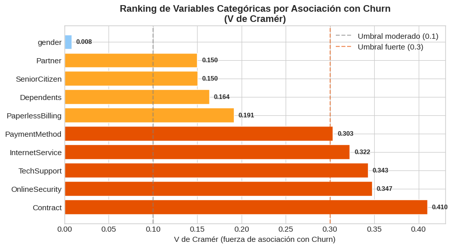

```python
# Ranking visual de variables por V de Cramér
ranking = sorted(resultados_chi2.items(), key=lambda x: x[1]['v'], reverse=True)
vars_orden = [r[0] for r in ranking]
vals_v     = [r[1]['v'] for r in ranking]

colores_barra = ['#E65100' if v >= 0.3 else '#FFA726' if v >= 0.1 else '#90CAF9'
                 for v in vals_v]

fig, ax = plt.subplots(figsize=(9, 5))
bars = ax.barh(vars_orden, vals_v, color=colores_barra, edgecolor='white')
ax.axvline(x=0.1, color='gray', linestyle='--', alpha=0.6, label='Umbral moderado (0.1)')
ax.axvline(x=0.3, color='#E65100', linestyle='--', alpha=0.6, label='Umbral fuerte (0.3)')
ax.set_xlabel('V de Cramér (fuerza de asociación con Churn)')
ax.set_title('Ranking de Variables Categóricas por Asociación con Churn\n(V de Cramér)',
             fontweight='bold')
ax.legend(frameon=False)
for bar, val in zip(bars, vals_v):
    ax.text(val + 0.005, bar.get_y() + bar.get_height()/2,
            f'{val:.3f}', va='center', fontsize=9, fontweight='bold')
plt.tight_layout()
plt.show()
```

*Pregunta 4:** ¿Qué variable categórica tiene la asociación más fuerte con Churn? ¿Y la más débil? ¿Por qué crees que `gender` tiene una V de Cramér tan baja?

**Respuesta 4:** *la mas fuerte seria Contract ya que indica la duracion de los contratos, por otro lado porque gender osea genero es tan bajo nos quiere decir que no importa si el cliente es hombre o mujer es decir no afecta*

**Pregunta 5:** Un estudiante dice: *"Chi-cuadrado de `gender` tiene p-value < 0.05, entonces el género sí está asociado al churn"*. ¿Está en lo correcto? ¿Qué le responderías con lo que aprendiste sobre la V de Cramér?

**Respuesta 5:** *lo que siento que aprendi es que el Chi cuadrado no es absoluto es decir con grandes volumenes de datos se puede volver sensible e impreciso es por eso que entra la V de Cramer que segun entendi nos dice que tan fuerte es esa relacion, es decir si es importante o si no*

### Ahora tú: Formula y verifica tu propia hipótesis

Elige **una variable** del dataset que creas que está relacionada con el churn y formula una hipótesis.

**Variables disponibles para explorar:** `OnlineSecurity`, `InternetService`, `PaperlessBilling`, `PaymentMethod`, `Dependents`, `Partner`, `SeniorCitizen`

**Mi hipótesis:**

> *"Los clientes que [OnlineSecurity y PaperlessBilling] tienen [Mayor] tasa de churn que los que [aquellos clientes que tengan una proteccion online son mas propensos a permanecer mas tiempo con el serivico al igual que con PaperLessBilling ]."*

## Paso 7: Matriz de correlación — Detección de multicolinealidad

La matriz de correlación nos permite ver dos cosas importantes:

1. Qué variables numéricas están más relacionadas con **Churn_num** (útil para el modelo)
2. Qué variables están muy relacionadas **entre sí** (problema de multicolinealidad)

**Pregunta 10:** `tenure` y `TotalCharges` tienen correlación r = 0.83. Si fueras a construir un modelo predictivo, ¿incluirías ambas variables o solo una? ¿Cuál elegirías y por qué?

**Respuesta 10:** *en mi caso probaria con ambas para poder ver si es que asi el modelo mejora o en su defecto ambas variables me dicen lo mismo y una tendria que eliminarse*

**Pregunta 11:** `tenure` tiene correlación negativa con `Churn_num` (r = -0.35). ¿Qué significa que la correlación sea negativa en este contexto de negocio?

**Respuesta 11:** _nos indica que los clientes con mayor tiempo contratando los servicios tienden a tener una mucho menor tasa de abandono y viceversa _

## Actividad Final: Síntesis — Informe para el equipo de negocio

**Contexto:** Eres analista de datos en TelcoPerú. El gerente de retención de clientes te pide un resumen ejecutivo basado en el análisis que acabas de realizar. Él no sabe estadística, pero necesita tomar decisiones esta semana.

Responde las siguientes preguntas **sin usar términos técnicos que él no entendería** (nada de p-value, Mann-Whitney o chi-cuadrado). Solo hallazgos claros y accionables.

**Pregunta A:** Resume en 3 puntos concretos quién es el cliente con mayor riesgo de abandonar la empresa (perfil de riesgo).

**Respuesta A:**

**Pregunta B:** El gerente dice: *"Si solo puedo hacer UNA cosa esta semana para reducir el churn, ¿qué me recomiendas?"* ¿Qué le responderías basándote en los datos?

**Respuesta B:** *Propondria implementar una promocion/campaña la cual le de especial enfasis a los clientes con contratos mensuales ofreciendoles incentivos o descuentos para que pasen de los contratos mensuales a los anuales*

**Pregunta C:** ¿Qué tipo de problema de Machine Learning es predecir el churn: clasificación, regresión o clustering? ¿Por qué? ¿Cuál sería la variable objetivo (target) y cuáles serían las variables predictoras (features) más prometedoras según tu análisis?

**Respuesta C:** _Seria un problema de clasificación binaria es decir 1/0, tiene o no tiene, el cliente se queda o no,nuestra variable objetivo seria Churn y las mas importantes varian ya que aun no hemos aplicado la seleccion de variables y evaluar mas exaustivamente sus correlaciones pero pondria (Contract, Tenure y MonthlyCharges) _

**Pregunta D:** El dataset tiene un 73.5% de clientes que NO cancelaron y solo un 26.5% que sí cancelaron. Si construimos un modelo que siempre predice "No Churn", ¿qué accuracy tendría? ¿Por qué ese modelo sería inútil para la empresa?

**Respuesta D:** _La precision seria de 73,5% y seria completamente inutil ya que si el modelo siempre predice que No entonces es completamente irrelevante ya que el objetivo es detectar a los posibles clientes que puedan cancelar y asi retenerlos _

**Pregunta E (desafío):** Propón una variable nueva que NO está en el dataset pero que crees que ayudaría mucho a predecir el churn. Justifica por qué.

**Respuesta E:** Número de llamadas a soporte técnico a lo largo del tiempo Ya que la insatisfaccion del cliente con el servicio suele ser una de las razones por las cuales los clientes tienden a dar de baja el servicio y de esta manera estariamos capturando que tan frecuentemente se contacta con servicio tecnico y su nivel de insatisfaccion